# EDA Zebrafish Embryo Behaviour - with pearson correlation metric and totaldist behavioural effect endpoint

Jory Curry

24 April 2022

# Rmd Report Assignment - BIOL5502

## Version Control

```r
# - My Machine Info:
#   - R version 4.1.3 (2022-03-10) -- "One Push-Up"
#   - Platform: x86_64-pc-linux-gnu (64-bit)         5.11.0-34-generic / Ubuntu 20.04.4
#   - Desktop: GNOME 3.36.5
#   - Hardware: CPU - Intel Core i5-9400F 6 core 4.1GHz / RAM - 15924MiB
# - Package Versions:
#   - lazyeval_0.2.2
#   - car_3.0-12
#   - tibble_3.1.6
#   - ggplot2 Package: Version 3.3.5
#   - dplyr Package: Version 1.0.8
#   - plyr_1.8.7
#   - tidyr: Version 1.2.0
#   - readr Package: Version 2.1.2
#   - stringr: 1.4.0
#   - data.table: 1.14.2
#   - car: 3.0-12
#   - DescTools_0.99.44
#   - Rcurvep_1.2.0
#   - rlang_1.0.2
```

## Background

About me: I come from an environmental ecotoxicology laboratory that explores the feasibility of using acute tests to estimate chronic toxicity for aquatic wildlife (e.g., early behavioural perturbation analyses, early metabolism analyses, and transcriptomic dose-response modelling).  
The data supplied in the zip folder pertains to behavioural data collected from 5 day-old (120hpf) zebrafish embryos using a [Viewpoint ZebraBox and Viewpoint ZebraLab software](https://www.viewpoint.fr/en/p/equipment/zebrabox-for-embryos-or-larvae/publications). This is real data that I collected!! It’s bound to have some errors.  
Chemical exposures are performed in glass petri dishes (3 dishes per dose group – A,B,C) for 120 hours post-fertilization.

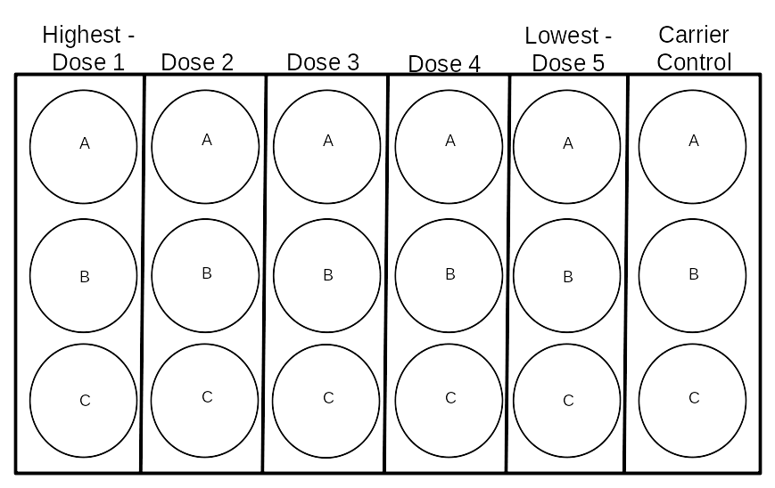

Figure 1. The experimental layout of the 5-day chemical exposures in petri dishes prior to the behavioural assay

On the final exposure day, embryos are pipetted into 96-Well plates. There are 26 experiments/plates included in the data set, each a unique chemical, and each with 6 different dose groups including a vehicle control group. There are 9 fish per dose group and 6 dose groups – 54 fish per plate

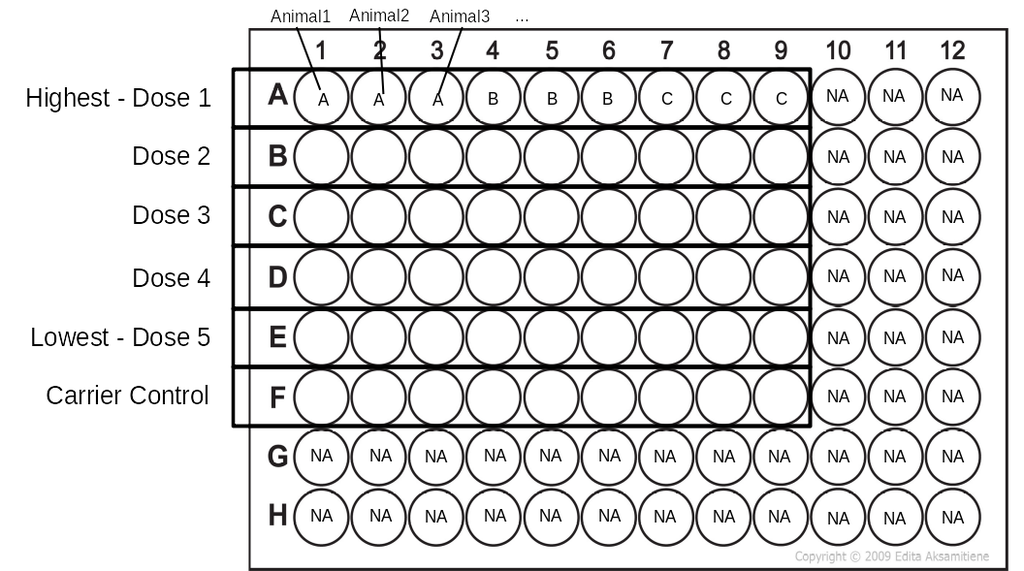

Figure 2. The behavioural assay plate layout for an individual experiment. In total, 54 5-day old embryos, 9 for each dose, are transferred to a 96-well plate in exposure media

The behavioural data is collected using an infrared camera over a 50-minute period where the first 20 minutes allow the zebrafish embryos to acclimate to their environment, and for the next 30 minutes there are 5-minute cycles of light and darkness – 96-well plate format. Zebrafish naturally tend to be more active in the dark. Neurotoxic chemicals may change the swimming behaviours of fish

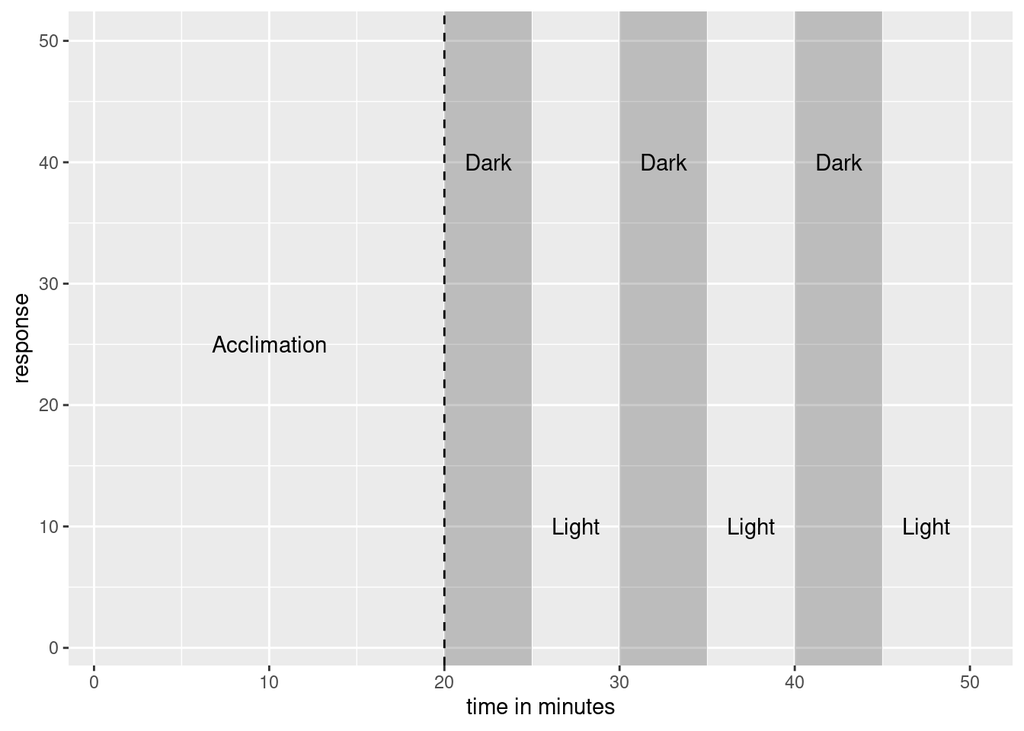

Figure 3. A visual representation of the behavioural assay protocol

The infrared camera traces the swim paths of fish during the entire experiment. A one-minute snapshot of raw swim paths look like this:

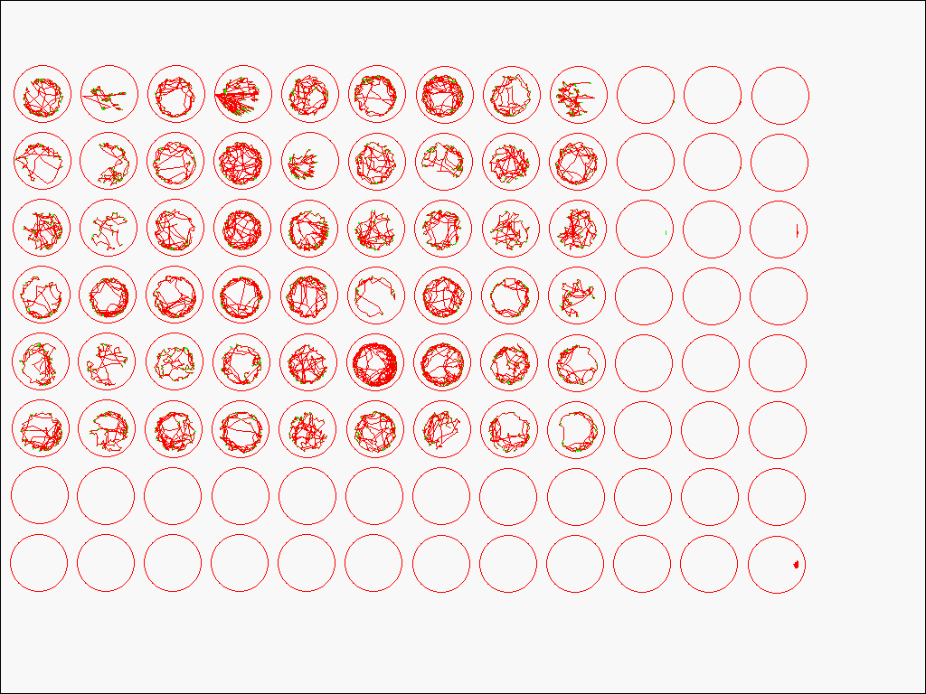

Figure 4. An example of what the raw swim-path tracing looks like from the Viewpoint Zebrabox infrared camera and Viewpoint Zebralab software

The raw data contain many variables that we will explore once we import the data. You can browse the meta data in the next section of this report.

## Directory & Meta Data

.XLS files have been converted to .csv files and are included in the directory /home/jorycurry/MolToxLab/Behaviour/Jory_Behaviour_R_Markdown/Data/All. These are the raw data files that this EDA will be using.

Table 1. Information about each chemical included in the experiment with dose information in mg/L

| Chemical Name | Plate ID | Mode of Action | Dose 1 (High) | Dose 2 | Dose 3 | Dose 4 | Dose 5 (Low) |
| --- | --- | --- | --- | --- | --- | --- | --- |
| 17b-Estradiol | 17beta_estradiol | ER binder (estrogenic) | 0.100 | 0.0100 | 0.00100 | 0.000100 | 0.0000100 |
| 1-Decanol | 1decanol | Polar Narcosis/weaker surfactant | 1.000 | 0.1000 | 0.01000 | 0.001000 | 0.0001000 |
| 1-Octanol | 1octanol | Polar Narcosis/weaker surfactant | 10.000 | 1.0000 | 0.10000 | 0.010000 | 0.0010000 |
| 2,4-Dimethylphenol | 24DMP | NA | 1.000 | 0.1000 | 0.01000 | 0.001000 | 0.0001000 |
| 2,4 Dinitrophenol | 24DNP | Respiratory un-coupler | 10.000 | 1.0000 | 0.10000 | 0.010000 | 0.0010000 |
| 3,4 dichloroanaline | 34DCA | NA (negative control for endrocrine disruption) | 1.000 | 0.1000 | 0.01000 | 0.001000 | 0.0001000 |
| 4-t Octylphenol | 4TOP | Weak ER | 0.100 | 0.0100 | 0.00100 | 0.000100 | 0.0000100 |
| 4-Tert Pentylphenol | 4TPP | Weak ER | 1.000 | 0.1000 | 0.01000 | 0.001000 | 0.0001000 |
| Aniline | Aniline | NA | 10.000 | 1.0000 | 0.10000 | 0.010000 | 0.0010000 |
| Bisphenol A | BPA | ER binder (estrogenic) | 1.000 | 0.1000 | 0.01000 | 0.001000 | 0.0001000 |
| Bisphenol AF | BPAF | ER binder (estrogenic) | 1.000 | 0.1000 | 0.01000 | 0.001000 | 0.0001000 |
| Clofibric Acid | Clofibric_Acid | PPAR alpha, and interferes with auxin | 10.000 | 1.0000 | 0.10000 | 0.010000 | 0.0010000 |
| Diethylstilbestrol | DES | ER binder (estrogenic) | 0.100 | 0.0100 | 0.00100 | 0.000100 | 0.0000100 |
| NN-Dimethylformamide | Dimethylformamide | NA | 1000.000 | 100.0000 | 10.00000 | 1.000000 | 0.1000000 |
| Dimethyl Sulfoxide | DMSO | Control | 10.000 | 1.0000 | 0.10000 | 0.010000 | 0.0010000 |
| Ethinyl estradiol | EE2 | ER binder (estrogenic) | 0.001 | 0.0001 | 0.00001 | 0.000001 | 0.0000001 |
| Fadrozole | Fadrozole | Aromatase inhibitor | 1.000 | 0.1000 | 0.01000 | 0.001000 | 0.0001000 |
| Fenitrothion | Fenitrothion | Cholisesterase inhibitor (neurotoxic) | 1.000 | 0.1000 | 0.01000 | 0.001000 | 0.0001000 |
| Fluoxetine | Fluoxetine | Selective Serotonin Re-uptake Inhibitor | 0.100 | 0.0100 | 0.00100 | 0.000100 | 0.0000100 |
| Flutamide | Flutamide | Anti-androgen | 1.000 | 0.1000 | 0.01000 | 0.001000 | 0.0001000 |
| Glyphosate | Glyphosate | Herbicide, amino acid inhibition | 1.000 | 0.1000 | 0.01000 | 0.001000 | 0.0001000 |
| Prochloraz | Prochloraz | Aromatase inhibitor/steroidogenesis inhibitor | 1.000 | 0.1000 | 0.01000 | 0.001000 | 0.0001000 |
| Sodium Dodceyl Sulfate | SDS | Polar Narcosis/stronger surfactant | 0.100 | 0.0100 | 0.00100 | 0.000100 | 0.0000100 |
| Triethylene Glycol | TEG | Polar Narcosis/weaker surfactant | 1000.000 | 100.0000 | 10.00000 | 1.000000 | 0.1000000 |
| Phenol, 4,4’-sulfonylbis[2-(2-propenyl)- | TGSH | ER binder (estrogenic) | 1.000 | 0.1000 | 0.01000 | 0.001000 | 0.0001000 |
| Vinclozolin | Vinclozolin | AR antagonist | 1.000 | 0.1000 | 0.01000 | 0.001000 | 0.0001000 |

## Importing the raw data files & taking a glimpse

Glimpse the raw data to see the structure of each variable, the number of observations and the class of the `raw_data` object

```
## Rows: 254,018
## Columns: 17
## $ plate_id  <chr> "17beta_estradiol", "17beta_estradiol", "17beta_estradiol", …
## $ animal    <chr> "Animal01", "Animal01", "Animal02", "Animal02", "Animal03", …
## $ Treatment <chr> "Dose1A", "Dose1A", "Dose1A", "Dose1A", "Dose1A", "Dose1A", …
## $ an        <lgl> FALSE, TRUE, FALSE, TRUE, FALSE, TRUE, FALSE, TRUE, FALSE, T…
## $ start     <dbl> 0, 0, 0, 0, 0, 0, 0, 0, 0, 0, 0, 0, 0, 0, 0, 0, 0, 0, 0, 0, …
## $ end       <dbl> 60, 60, 60, 60, 60, 60, 60, 60, 60, 60, 60, 60, 60, 60, 60, …
## $ inact     <int> 25, 25, 81, 81, 93, 93, 75, 75, 87, 87, 78, 78, 69, 69, 72, …
## $ inadur    <dbl> 1.3, 1.3, 15.5, 15.5, 16.3, 16.3, 22.1, 22.1, 17.8, 17.8, 9.…
## $ inadist   <dbl> 0, 0, 0, 0, 0, 0, 0, 0, 0, 0, 0, 0, 0, 0, 0, 0, 0, 0, 0, 0, …
## $ smlct     <int> 289, 289, 188, 188, 157, 157, 111, 111, 164, 164, 181, 181, …
## $ smldur    <dbl> 34.0, 34.0, 29.5, 29.5, 40.5, 40.5, 32.6, 32.6, 34.9, 34.9, …
## $ smldist   <dbl> 912.2, 912.2, 488.8, 488.8, 659.8, 659.8, 511.7, 511.7, 568.…
## $ larct     <int> 282, 282, 149, 149, 82, 82, 52, 52, 94, 94, 139, 139, 106, 1…
## $ lardur    <dbl> 23.7, 23.7, 14.8, 14.8, 3.1, 3.1, 5.3, 5.3, 7.1, 7.1, 24.6, …
## $ lardist   <dbl> 1283.6, 1283.6, 714.0, 714.0, 75.5, 75.5, 306.1, 306.1, 270.…
## $ emptyct   <int> 27, 0, 6, 0, 0, 0, 0, 0, 1, 0, 12, 0, 4, 0, 2, 0, 1, 0, 1, 0…
## $ emptydur  <dbl> 1.0, 0.0, 0.2, 0.0, 0.0, 0.0, 0.0, 0.0, 0.1, 0.0, 0.5, 0.0, …
## [1] "tbl_df"     "tbl"        "data.frame"
```

From the glimpse it can be seen that there are 17 variables in the tibble/data frame:

- `plate_id` the chemical used in the exposure experiment
- `animal` represents individual animals in the experiment
- `Treatment` The Dose group, and internal replicate (petri dish A, B or C)
- `an` Unknown/not useful
- `start` start time of observation in seconds
- `end` end time of observation in seconds
- `inact` Inactivity Counts | the number of times the fish went from being active to inactive over the observation time
- `inadur` Inactivity Duration | the duration of time, in seconds, the fish went from being active to inactive over the observation time (1 minute)
- `inadist` Inactivity Distance | the distance travelled by inactive observations (this value should be 0)
- `smlct` Small Activity Counts | the number of times the fish had a small burst of swim activity over the observation time (1 minute)
- `smldur` Small Activity Duration | the duration of the small burst of swim activity over the observation time (1 minute)
- `smldist` Small Activity Distance | The distance travelled during small bursts of activity
- `larct` Large Activity Counts | the number of times the fish had a large burst of swim activity over the observation time (1 minute)
- `lardur` Large Activity Duration | the duration of the large burst of swim activity over the observation time (1 minute)
- `lardist` Large Activity Distance | The distance travelled during large bursts of activity
- `emptyct` Counts that were neither inactive or active (data recording artifact)
- `emptydur` duration of time fish was neither inactive, or active (data recording artifact) | Almost acts like a confidence value. The closer it is to 60, the more unreliable the data are

## Investigating `raw_data`

### Checking expectations

#### Number of observations/rows

It is expected that the raw data wil have 124800 rows because there are 96 wells, 50 minutes, and 26 different plates

```r
nrow(raw_data)
## [1] 254018
```

However, there are 254018 rows present in the raw data. This expectation was violated because each observation is duplicated

```
## # A tibble: 254,018 × 8
##    plate_id         Treatment an      end smldist lardist emptyct emptydur
##    <chr>            <chr>     <lgl> <dbl>   <dbl>   <dbl>   <int>    <dbl>
##  1 17beta_estradiol Dose1A    FALSE    60    912.  1284.       27      1
##  2 17beta_estradiol Dose1A    TRUE     60    912.  1284.        0      0
##  3 17beta_estradiol Dose1A    FALSE    60    489.   714         6      0.2
##  4 17beta_estradiol Dose1A    TRUE     60    489.   714         0      0
##  5 17beta_estradiol Dose1A    FALSE    60    660.    75.5       0      0
##  6 17beta_estradiol Dose1A    TRUE     60    660.    75.5       0      0
##  7 17beta_estradiol Dose1B    FALSE    60    512.   306.        0      0
##  8 17beta_estradiol Dose1B    TRUE     60    512.   306.        0      0
##  9 17beta_estradiol Dose1B    FALSE    60    569.   271.        1      0.1
## 10 17beta_estradiol Dose1B    TRUE     60    569.   271.        0      0
## # … with 254,008 more rows
```

By looking at just the head of `raw_data`, it can be seen that the variable `an` has a `TRUE` and `FALSE` row for each individual observation. The only difference between these duplicate rows is that the `FALSE` rows retain information about `emptyct` and `emptydur`.

```r
raw_data <- raw_data %>%
  filter(an == FALSE) %>% # Removing duplicate rows
  select(-c(an)) # This variable is not very useful anymore, so removing
nrow(raw_data)
## [1] 127009
```

After filtering for just the false values, there are now 127009 rows. There are 2209 extra observations in `raw_data` because there are some extra observations past 50 minutes.

```r
raw_data <- raw_data %>%
  filter(end <= 3000) # Deleting observations past 50 mins (3000 seconds)
nrow(raw_data)
## [1] 124800
identical(as.numeric(nrow(raw_data)), (96 * 50 * 26)) # is the expected number of rows consistent with the observed number of rows after processing?
## [1] TRUE
```

After ensuring there are no observations past the 50-minute mark, there are now 124800 rows, as expected.

#### Treatment-level NAs

It is expected that wells 10:12, 22:24, 34:36, 46:48, 58:60, 70:96 will all be `NA` in the `Treatment` column because these are all empty wells (Figure 2). Each plate has 42 empty wells. This means that all `NA` treatments should be 54600 observations long. After removing `NA`s there should be 70200 rows in `raw_data`.

```r
raw_data <- raw_data %>%
  filter(Treatment != is.na(Treatment))
nrow(raw_data)
## [1] 70200
identical(as.numeric(nrow(raw_data)), (54 * 50 * 26)) # Does the expected number of rows match the observed number of rows after filtering?
## [1] TRUE
```

#### Variable Distributions

Quick visualizations of the distributions of each variable are a fast and easy way to learn a lot about the data such as the range, distribution of observations, and outliers.  
First, the ‘counts’ variable distributions will be investigated.

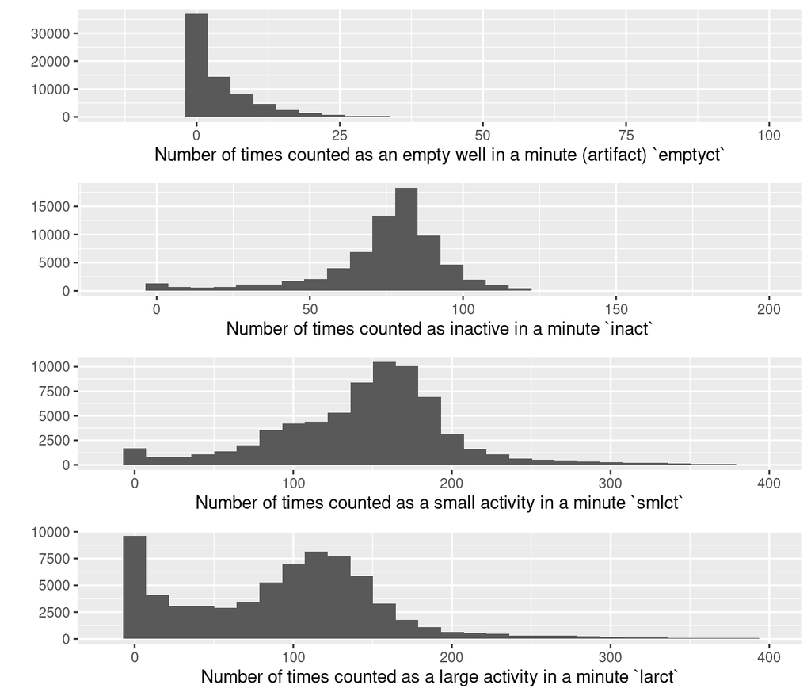

Figure 5. Quick plots of the ‘counts’ variables in the `raw_data` object

Figure 5 (plot 1) shows that there are some artifacts in the data. Sometimes, the camera/software was not able to detect a fish even though, there certainly were fish in those wells. The `emptyct` variable (plot 1) is a good tool to use for flagging observations that need to transformed to `NA`s in the next section (Suspicious Values).  
It can be seen that the amount of times an animal goes inactive during an observation period (`inact`) is approximately 75 times per minute. As well, it can be seen that small swim bursts (`smlct`) tend to occur just over 150 times per minute. And finally, we can see that large swim bursts (`larct`) can either occur just over 100 times per minute, or 0 times per minute. This could be due to sensitive effects of light on swim inhibition, or darkness stimulating large swim behaviours.  
The distributions of all count variables are slightly skewed, with few outliers, except for the empty well counts which are very positively skewed.  
Next, the ‘duration’ variable distributions will be explored. Note: this variable should never exceed 60 seconds.

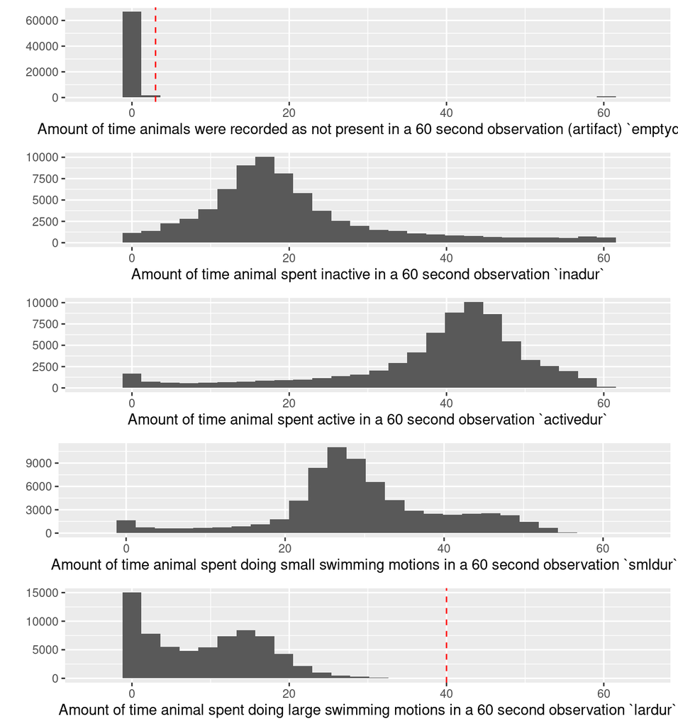

Figure 6. Quick plots of the ‘duration’ variables in the `raw_data` object

Figure 6 reveals another red flag with the `emptydur` variable (plot 1 in figure 6). There are some observations that show 60 full seconds of being empty! This is likely more than just an artifact in the recording instrument/software. These are likely dead fish that never moved at all so the infrared camera was never able to start tracing their swim patterns. However, it can also be seen that there are some observations greater than 0 and less than 60 in this plot. In theory, if an animal is present in the well, the `emptydur` value should always be zero. An arbitrary threshold of 3 seconds of empty duration will be used to transform all observations (across variables) with an `emptydur` > 3 into `NA`s  
Again, it can also be seen that the distributions of observations for each variable is slightly skewed. Note also that `inadur` and `activedur` (plots 2 and 3 from figure 6) are approximately inversely related as expected. The emerging pattern of large swim activity duration (`lardur`) clustering around two modes (0s and ~15s) can be observed, similar to the counts variable.  
There are a few outliers in the data but they are a bit difficult to see in figure 6. Notably, large swim activity duration (plot 5 in figure 6) has 27 outliers past ~40 seconds. Taking a closer look at those outliers…

Table 2. Summary of outliers in large swim activity duration variable (> 40s), showing only unique individuals

| Chemical | Individual | Dose | Large Activity Duration (seconds) |
| --- | --- | --- | --- |
| BPA | Dose1B | Animal06 | 46.96667 |
| Dimethylformamide | Dose1B | Animal06 | 42.20000 |
| Fadrozole | Dose1A | Animal02 | 42.45000 |
| Fadrozole | Dose5B | Animal54 | 40.50000 |
| Fluoxetine | Dose1A | Animal02 | 42.20000 |
| Flutamide | Dose4B | Animal41 | 41.12500 |
| Vinclozolin | Dose1B | Animal06 | 44.60000 |
| Vinclozolin | Dose5A | Animal49 | 42.60000 |

Behavioural perturbation (hyperactivity) suggests that it is possible that these chemicals can effect the nervous system of individuals early on in development. However, it is wise to be cautious and not draw any conclusions yet without any sort of statistical analyses.  
Next, the distributions of the ‘distance’ variables will be investigated.

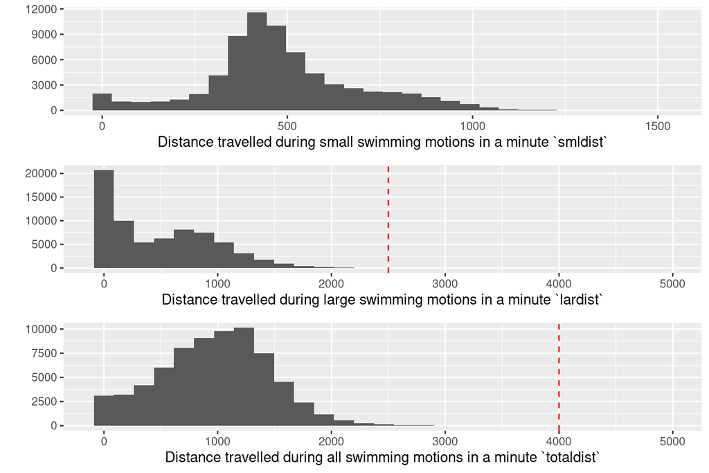

Figure 7. Quick plots of the ‘distance’ variable in the `raw_data` object

Figure 7 shows that the distributions of of the ‘distance’ variables are slightly skewed with the `totaldist` variable being the most normally distributed. Notably, `totaldist` seems to be a promising effect endpoint to analyse since it is the most normally distributed of all the other effect endpoints.  
However, there are outliers in `totaldist` and so the following steps will be taking a closer look at those outliers…

Table 3. Summary of outliers in total distance travelled variable (>4000) showing only unique individuals

| Chemical | Dose | Individual | Distance travelled in 1 min |
| --- | --- | --- | --- |
| BPA | Dose1B | Animal06 | 6880.433 |
| Fadrozole | Dose1A | Animal02 | 4429.550 |
| Fadrozole | Dose1B | Animal04 | 4149.900 |
| Fadrozole | Dose2B | Animal17 | 4155.800 |
| Vinclozolin | Dose1B | Animal06 | 4316.580 |

We see there are 3 chemicals in the extreme outliers, and that most of the individual animals are from the highest dose treatment group:  
Chemicals observed in extremely hyperactive individuals:

- Bisphenol A (BPA) – estrogen receptor binder
- Fadrozole – aromatase inhibitor (estrogen blocker)
- Vinclozolin – androgen antagonist (testosterone blocker)

Again, we see 3 of the same chemicals that are potentially inducing hyperactivity in the same individuals. However, as previously stated, these individuals are not representative of the rest of the population within their respective dose groups and no conclusions can be drawn yet!  
It is important to also consider determining outliers not just between plates in the larger data frame, but within the same plate.

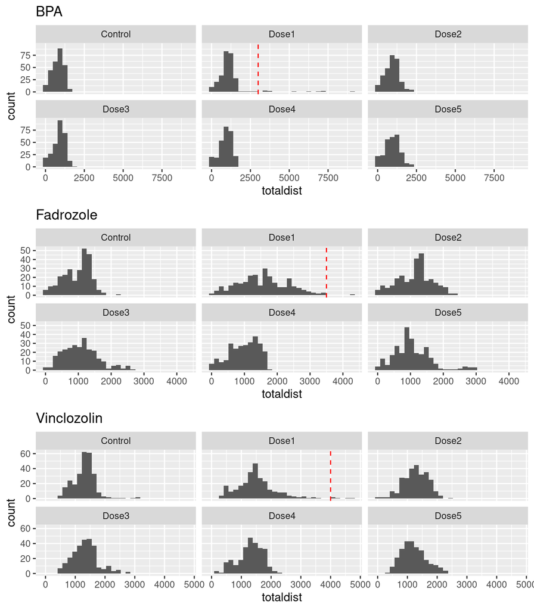

Figure 8. Example of within-plate outlier quick plots

After a careful examination of individual plates, the following outliers were identified in the `totaldist` variable:

Table 4. Summary of outliers in `raw_data` grouped by chemical and dose group

| Chemical | Dose | Number of outlier observations (totaldist) |
| --- | --- | --- |
| Fadrozole | Dose1 | 16 |
| BPA | Dose1 | 11 |
| TGSH | Dose1 | 11 |
| TGSH | Dose3 | 7 |
| Fadrozole | Dose2 | 6 |
| Clofibric_Acid | Dose4 | 5 |
| Vinclozolin | Dose1 | 5 |
| Clofibric_Acid | Control | 4 |
| Clofibric_Acid | Dose2 | 4 |
| Clofibric_Acid | Dose3 | 4 |
| EE2 | Dose4 | 4 |
| 17beta_estradiol | Dose2 | 2 |
| Clofibric_Acid | Dose5 | 2 |
| DES | Dose3 | 2 |
| DES | Dose5 | 2 |
| EE2 | Dose1 | 2 |
| Fluoxetine | Dose1 | 2 |
| 17beta_estradiol | Dose4 | 1 |
| 24DMP | Dose1 | 1 |
| Clofibric_Acid | Dose1 | 1 |
| DES | Dose2 | 1 |
| TGSH | Control | 1 |

It can also be noted that the most represented dose group in the outliers is dose group 1 (the highest dose):

Table 4. Summary of outliers in `raw_data` grouped by dose

| Dose | Number of outlier observations (totaldist) |
| --- | --- |
| Dose1 | 49 |
| Dose2 | 13 |
| Dose3 | 13 |
| Dose4 | 10 |
| Control | 5 |
| Dose5 | 4 |

This suggests that the effects of chemical exposure could be behaving monotonically:

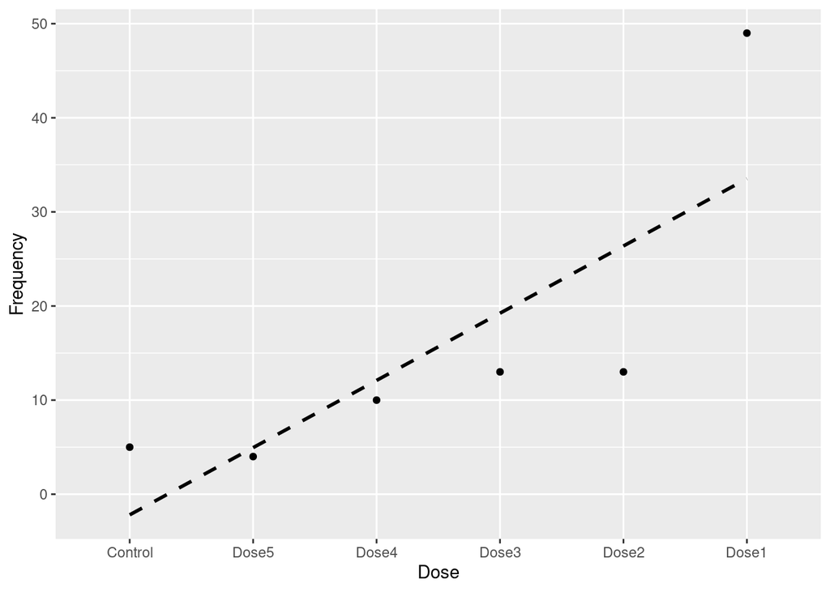

Figure 9. Monotonic relationship of outlier observations (totaldist) and dose groups

However, removing these outliers from the data set could be artificially masking the most extreme effects of exposure on individuals (especially in the highest dose). Therefore, the outliers should be kept in the data set to avoid removing any observations that could be the result of chemical exposure. But, they will be flagged as outliers in `raw_data`.